# GRUPO 6: MEMORIA AA1

## NEds

```r
#Resumen de los datos
summary(train_Data$NEds)
```

```
##    Min. 1st Qu.  Median    Mean 3rd Qu.    Max.
##      50      92     216    2224     754  153193
```

Observamos que el primer cuartil es bajo, por lo que tenemos una gran concentración de datos con valores bajos. La media es muy superior a la mediana, lo que va a presentar asimetría a la derecha. También se observa que el máximo de ediciones es (153193), dato que es erroneo.

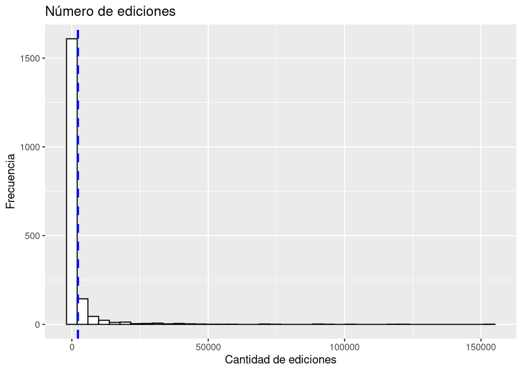

```r
#Veamos el histograma.
histogram(NEds,x_label = "Cantidad de ediciones", y_label = "Frecuencia",title = "Número de ediciones" )
```

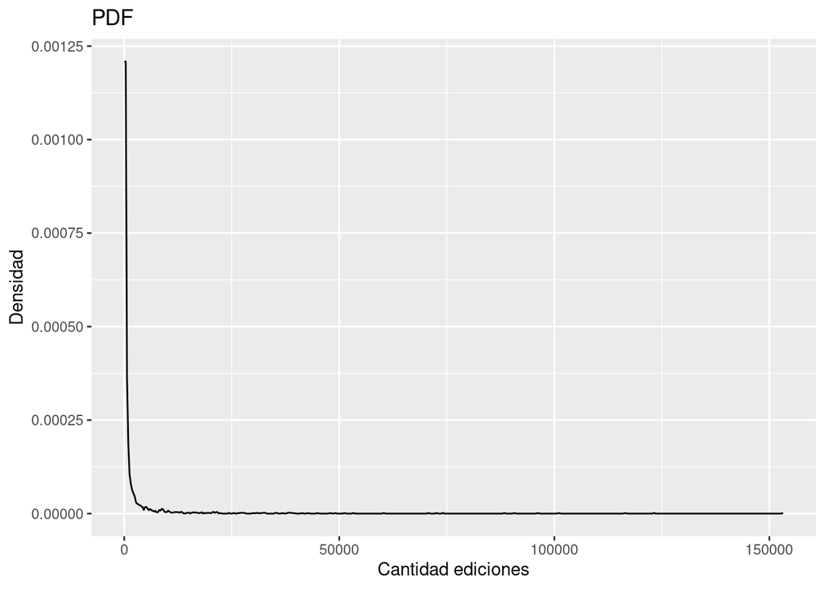

```r
#NEds - pdf
pdf(NEds, x_label = "Cantidad ediciones")
```

*Se observa que la probabilidad se encuentra concentrada en valores bajos*

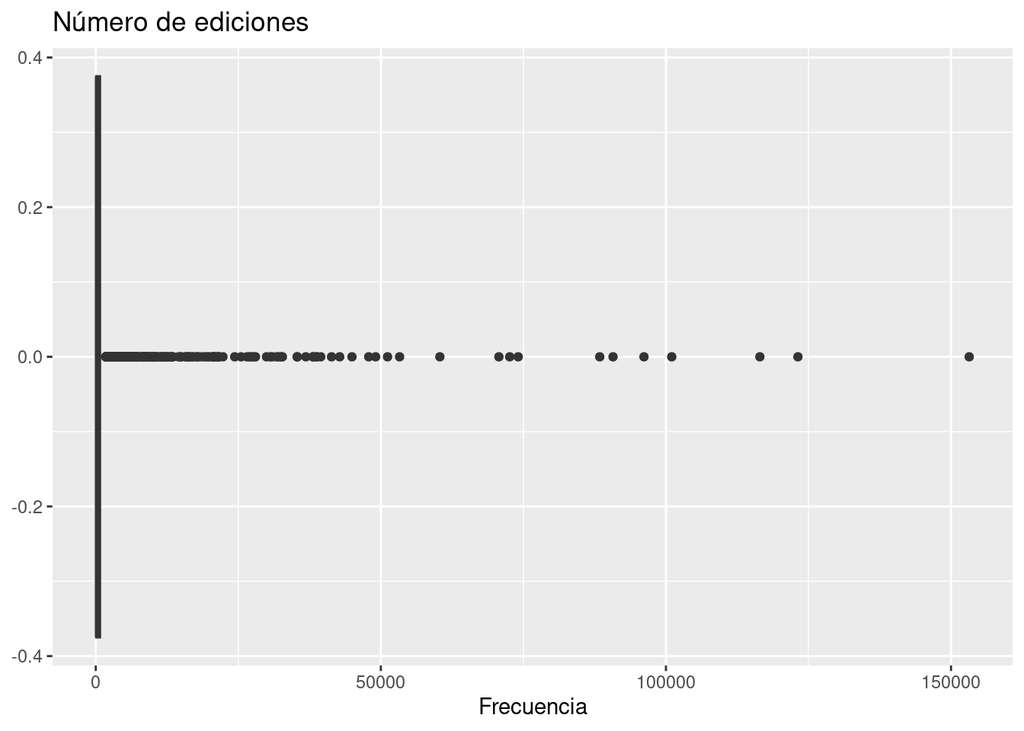

```r
boxplot(NEds,title = "Número de ediciones", x_label = "Frecuencia")
```

*Se observa que el valor máximo está muy alejado de los otros valores atípicos, lo que apoya el pensamiento de que puede ser un dato erróneo.*

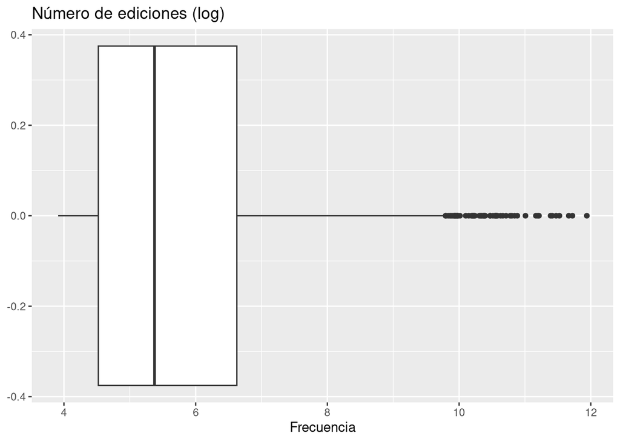

```r
#log(NEds) - Boxplot
boxplot(log(NEds),title = "Número de ediciones (log)", x_label = "Frecuencia")
```

*Realizando un boxplot al logaritmo de la variable se aprecian mejor los valores atípicos. Hay una gran cantidad de ellos.*